# Math 220 Spring 2023 Lecture Notes

A: sure, why not.

Ex). iris petal length

```r
head(iris)
```

```
##   Sepal.Length Sepal.Width Petal.Length Petal.Width Species
## 1          5.1         3.5          1.4         0.2  setosa
## 2          4.9         3.0          1.4         0.2  setosa
## 3          4.7         3.2          1.3         0.2  setosa
## 4          4.6         3.1          1.5         0.2  setosa
## 5          5.0         3.6          1.4         0.2  setosa
## 6          5.4         3.9          1.7         0.4  setosa
```

hist:

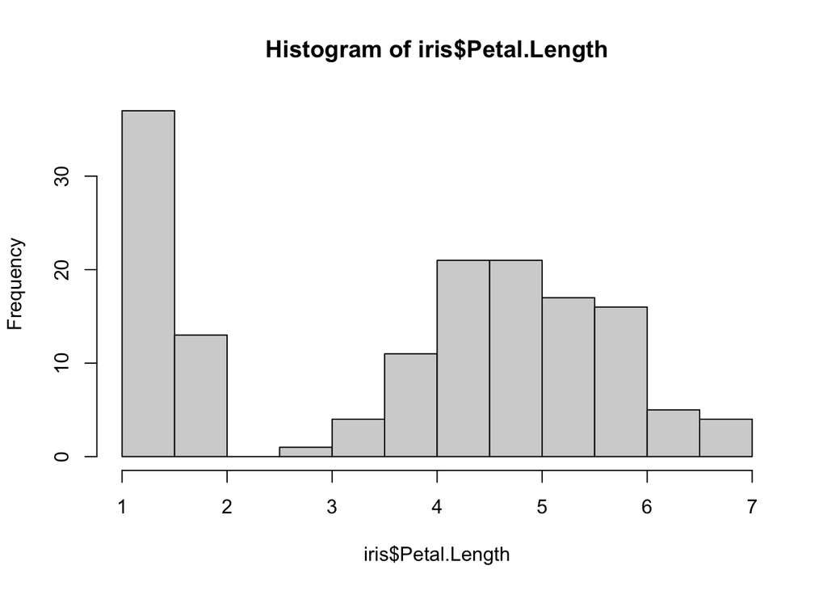

```r
hist(iris$Petal.Length)
```

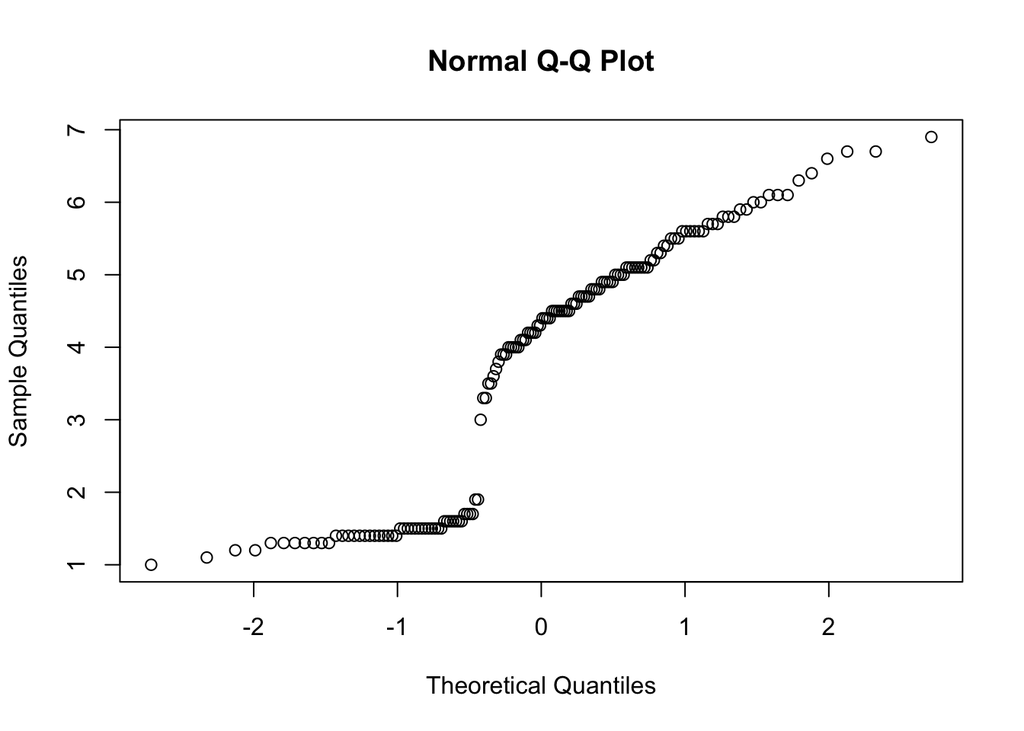

```r
qqnorm(iris$Petal.Length)
```

Oof! Super not linear, data does -not- follow a normal dist.

### Skip 5.1-5.2

### 5.3 - Sampling Distributions

So far: we’ve talked about INDIVIDUALS.

Ex). What’s prob that rando woman is at least 65” tall?

Now: want to talk about entire SAMPLE STATISTICS (think: xbar, phat).

Ex. In a sample of 10 women, what’s the prob their AVERAGE HEIGHT is at least 65” tall?

A SAMPLING DISTRIBUTION is a prob dist that describes the likelihood of entire SAMPLE RESULSTS (xbar, phat).

Ex) Roll 2 dice, take average = xbar. n = 2. Construct the samp dist for xbar.

### CENTRAL LIMIT THEOREM

CLT: As long as n is “large enough”, then the samp dist for xbar follows an approximately normal dist, NO MATTER WHAT POPULATION WE’RE SAMPLING FROM!!!!!

mean: “the mean of the mean is the mean” “our expectation for xbar is the same as the population mean, mu”

variance: cut down by factor of n

Ex) What’s prob that rando woman is at least 65” tall?

Recall: mu = 64, sigma = 2.4.

z-score:

```r
(65-64)/2.4
```

```
## [1] 0.4166667
```

right area:

```r
1-pnorm(.42)
```

```
## [1] 0.3372427
```

Ex) Sample n=10 women. WHat’s the prob their AVERAGE height is at least 65”?

xbar ~ normal

mu_xbar = 64 sigma_xbar = 2.4/sqrt(10)

z-score!

```r
(65-64)/(2.4/sqrt(10))
```

```
## [1] 1.317616
```

right area:

```r
1-pnorm(1.32)
```

```
## [1] 0.09341751
```

About 9.3% chance that 10 women have mean height at least 65”.

### Is n large enough?

2 cases:

- If we’re sampling from a normal population (think: height), then xbar is normal no matter what, even for small n.
- If we’re sampling from a NON-NORMAL (or UNKNOWN) population, then NEED LARGE n in order to use normal dist (CLT).

  ```
  "large enough":  n >= 30
  ```

# Week 7

## Monday Feb 27

### 5.3-5.5 Sampling Distributions

Last: samp dist for xbar

Now: samp dist for phat (sample proportion)

### CLT for phat

If sample size (n) is large enough, then phat follows an (approximately) normal dist, NO MATTER WHAT POPULATION WE’RE SAMPLING FROM!!!

Large enough:

- n*p >=10. (at least 10 successes)
- n*(1-p) >=10 (at least 10 failures)

z = (obs - exp)/stdev

mean: expectation for sample proportion is the pop proportion!

Ex). Voters in a particular county are 55% R. 45% D.

If we take a sample of 100 people, what’s the prob that half or fewer are R?

P( phat <= .5 )

Is n large enough?

n*p:

```r
100*.55
```

```
## [1] 55
```

n*(1-p)

```r
100*(1-.55)
```

```
## [1] 45
```

normal dist! get z-score!

z = (obs - exp)/stdev

obs = .5

exp = .55

stdev = sqrt(.55*(1-.55)/100)

```r
(.5 - .55)/sqrt(.55*(1-.55)/100)
```

```
## [1] -1.005038
```

find are on table:

```r
pnorm(-1.01)
```

```
## [1] 0.1562476
```

About 15.6% chance that fewer than half in our sample are R.

### Ch 6: Parameter Estimation

Q: what the heck ARE all these parameters we’re talking about?

mu? sigma? p? lambda?

A: guess (estimate!) based on data!

Think:

Best guess for mu is: xbar!

Best guess for p: phat

Best guess for sigma: s (samp stdev)

Best guess for lambda (exponential dist): ???????

A POINT ESTIMATE is a single number representing a reasonable guess about a parameter.

Big question: how to find it? The “best guess” is not always obvious!

3 strategies:

- unbiased estimators
- method of moments
- max likelihood estimators (MLEs)

### Unbiased

Ex). Show that xbar is an unbiased estimator for mu.

Ex). Show that phat is unbiased estimator for p.

Practice: Show that s^2 is unbiased estimator for sigma^2 (solution: p253)

### Method of Moments

Example 6.12

## Wed Mar 1

### 6.2 Parameter estimation

- unbiased
- m.o.m
- m.l.e

### Method of Moments

2 kinds:

- moment for distribution
- moment for data

MoM: match up the moments! solve for parameters!

Note: how many moments do we need? answer: as many as the number of parameters.

Ex). Suppose x1, x2, …, xn are sampled from EXPONENTIAL distrubion. Use MoM to estimate lambda.

Ex). x1, … xn are sampled from NORMAL dist. Use MoM to estimate mu and sigma.

### Max Likelihood Estimator (MLE)

Likelihood function:

probability of observing OUR sample result (x1, x2, ..,xn) GIVEN the value of the params

MLE: find choice of params that MAXIMIZES (calculus!) the likelihood function

Ex). Use MLE to find estimate for lambda in exponential dist.

1). get joint pdf

2. sneaky trick: take log of both sides

3). take deriv, set =0. (ie find max!) [NOTE: take deriv with respect to LAMBDA!!!]

Ex). 6.22 (p273)

Find estimate for theat using a) MoM and b) MLE

## Friday Mar 3

### 6.2 MoM and MLE

Ex) Use MLE to estimate mu and sigma for normal dist.

Last time, for both unbiased AND M.O.M:

mu = xbar sigma = s

WARNING: must take deriv with respect to BOTH mu and sigma (not at the same time).

Idea: two equations, two unknowns!

Conclusion: MLE estimator for mu is the same (xbar), BUT the estimator for sigma is DIFFERENT! The MLE is BIASED!!!

### Ch7 - Confidence Intervals

Idea: what’s a RANGE of reasonable values for the parameter (mu, sigma, p, lambda, etc etc), how sure are we the true value is in there?

Ex). Height for adult men is normal with mean 69”, stdev 2.7”.

mu = 69, sigma = 2.7

If we take a sample of n=36 men, what are the cutoffs for the middle 95% of such sample means?

Q: is xbar normal?

A: two cases:

- if X is normal, then so is xbar (even small n)
- if n is large (>=30), then xbar is normal for any population

Middle 95% -> tail area = 2.5% -> z = +/- 1.96

```r
qnorm(.025)
```

```
## [1] -1.959964
```

lo:

```r
69-1.96*2.7/sqrt(36)
```

```
## [1] 68.118
```

hi:

```r
69+1.96*2.7/sqrt(36)
```

```
## [1] 69.882
```

### Conf Int

Idea: capture the middle 90%/95%/99% of the sampling distribution.

What are reasonable values of mu based on xbar?

Problem: what about sigma?

Temp solution: for large n (n>=30), s is a good approximation for sigma.

Ex) A biologist wonders: what’s the mean height of reticulated giraffes? Collect data on 40 giraffes, their mean height is 18.2’, stdev 1.7’.

Construct a 95% C.I for the true mean height of giraffes.

Here: critical value = z_alpha = 1.96

plug and chug!

low:

```r
18.2 - 1.96*1.7/sqrt(40)
```

```
## [1] 17.67316
```

hi:

```r
18.2 + 1.96*1.7/sqrt(40)
```

```
## [1] 18.72684
```

We are 95% confident that the true population mean of all reticulated giraffes is btwn 17.67 and 18.72 ft tall.

Is this the same as: ??

There’s a 95% chance that mu is btwn 17.67 and 18.72.

NO! To be continued…

```r
ourData <- sample(1:6,30, replace=TRUE)

mean(ourData) - .67*sd(ourData)/sqrt(30)
```

```
## [1] 2.923336
```

```r
mean(ourData) + .67*sd(ourData)/sqrt(30)
```

```
## [1] 3.343331
```

```r
qnorm(.25)
```

```
## [1] -0.6744898
```

# Week 8

## Monday March 6

### Ch 7 - Confidence Intervals

Idea: want best guess for pop parameter based on data!

ESTIMATE!!!!

Ex). Prof Miller wonders: what’s the true mean volume of coffee she pours in the morning?

Collects data on 50 days. Mean volume = 8.2, stdev 1.7oz.

Estimate the true mean volume with 99% confidence.

tail area = .005 -> 2.58

```r
qnorm(.005)
```

```
## [1] -2.575829
```

plug and chug!

```r
8.2 - 2.58*1.7/sqrt(50)
```

```
## [1] 7.579726
```

```r
8.2 + 2.58*1.7/sqrt(50)
```

```
## [1] 8.820274
```

We are 99% confident that the true mean volume of morning coffee is between 7.58oz and 8.82oz.

### What does CONFIDENCE really mean?

Ex). Dice rolls! Goal: use sample data to approximate mean value of dice throw.

Note: we know that mu = 3.5

dice sample: (n=10)

```r
sample(1:6, 10, replace = T)
```

```
##  [1] 6 6 6 2 5 6 2 1 2 1
```

Take sample of size n=50, construct 50% CI:

```r
ourData <- sample(1:6, 50, replace = T)
ourData
```

```
##  [1] 4 2 5 4 1 5 5 1 3 2 5 4 6 3 6 3 5 5 5 4 1 5 5 3 6 2 5 2 5 5 5 3 5 6 6 5 3 4
## [39] 2 2 4 2 6 4 3 6 4 5 1 3
```

```r
mean(ourData) - qnorm(.25)*sd(ourData)/sqrt(50)
```

```
## [1] 4.066562
```

```r
mean(ourData) + qnorm(.25)*sd(ourData)/sqrt(50)
```

```
## [1] 3.773438
```

MORAL OF THE STORY: the cofindence level is about the METHOD used for constructing CI, it is NOT about the individual bounds you calculated.

You have NO IDEA if your interval was successful or not.

### Margin of error

Math: everyting after the +/- in formula.

Goal: make MOE small! Two factors that affect MOE:

- sample size (n). As sample size increases, the MOE for CI decreases

  Think: yaaaay!
- confidence level. As confidence increases, the MOE for CI BIGGER MOE!!!

  Think: bummer!

### Planning ahead for sample size

Recall, the MOE in coffee examle was:

```r
2.58*1.7/sqrt(50)
```

```
## [1] 0.6202741
```

Suppose we wish to conduct a follow-up study that estimates the true volume within 0.1 oz, at 99.9% confidence.

How large must our samle be?

Idea: plug in to MOE formula, solve back for n.

Info:

MOE < .1 z = 3.29

```r
qnorm(.0005)
```

```
## [1] -3.290527
```

prior estimate for sigma = 1.7oz

plug in!

```r
(3.29*1.7/.1)^2
```

```
## [1] 3128.165
```

Need n at least 3129.

Note: might need to compromise! Maybe either less confidence, OR accept a bigger margin of error.

## Wed March 8

### CH 7: CIs

So far: CI for mu (large n)

Q: wait. if we don’t know mu, how the heck do we know sigma?

A: swap out for s (ok if n large, since s is unbiased).

Q: what if n is small?

before:

z = (xbar - mu)/(sigma/sqrt(n))

now:

t = (xbar - mu)/(s/sqrt(n))

### the t dist

The t dist comes from using s instead of sigma.

Derivation: grad school!

Neat t facts:

- t dist looks awful lot like z dist
- weird thing: shape of the t dist depends on the sample size
  - n larger -> t gets closer to normal. (basically no difference after n=100)
- t dist has thicker tails than normal dist (always)

Q: are t-intervals wider or narrower than z-intervals?

A: t always wider! more stuff in the tails!

Think: bummer! bigger MOE with t dist!

It’s the price we pay for not knowing sigma.

### t table

WARNING: t table is BACKWARDS from z table!

In the t-table:

- values IN the table are t-scores
- area on top margin

Note: need DEGREES OF FREEDOM

```
 df = n-1
```

Ex). Suppose we wish to estimate mu with 95% confidence from sample with n=15.

Note: it’s ESSENTIAL to use t here, not z!

t = 2.145

```r
qt(.025,14)
```

```
## [1] -2.144787
```

Ex) Estimate mu with 99% confidence, n=20.

What’s t?

t = 2.861

Ex) A researcher wonders, what’s the mean height for women in Sweden?

Collect data from 12 women in Sweden, find mean height 65.2”, stdev 2.5”.

Estimate the true mean height with 90% confidence.

t = 1.796

```r
65.2 - 1.796*2.5/sqrt(12)
```

```
## [1] 63.90385
```

```r
65.2 + 1.796*2.5/sqrt(12)
```

```
## [1] 66.49615
```

We are 90% confident that true mean height for Swedish women is btwn 63.9” and 66.5”.

### Conf Int for p

Ex). What proportion of DU students will travel out-of-state for break?

random sample of 100 students: 53 of them say “yes”, travel.

Estimate the true proportion of travelling students with 94% confidence.

```r
qnorm(.03)
```

```
## [1] -1.880794
```

z = 1.88

plug and chug!

```r
.53 - 1.88*sqrt(.53*(1-.53)/100)
```

```
## [1] 0.4361694
```

```r
.53 + 1.88*sqrt(.53*(1-.53)/100)
```

```
## [1] 0.6238306
```

We’re 94% confident that the true prop of travelling students is btwn 44% and 62%.

Q: what if we wanted smaller MOE?

MOE:

```r
1.88*sqrt(.53*(1-.53)/100)
```

```
## [1] 0.09383065
```

### Plan ahead for sample size

Ex). Suppose we wish to conduct a future study that estimate the prop to within 1% and 95% confidence.

Idea: plug in to MOE formula, solve back for n

prior estimate for p = .53

z = 1.96

MOE = .01

```r
.53*(1-.53)*(1.96/.01)^2
```

```
## [1] 9569.426
```

Q: what if no prior estimate for p?

A: use = .5. Worst-case scenario.

# Week 9

## Monday March 20

Recall CLT: As long as n is large, then our sample statistics (like xbar and phat) follow a normal dist, NO MATTER WHAT POPULATION WE’RE SAMPLING FROM!!!

### Ch 8: Hypothesis Tests

Ex). A researcher suspects that women in sweden have higher mean height then women in the US.

Data: a random sample of 50 swedish women have mean height of 65.1”, stdev 2.8”.

Does this provide evidence that mean height for swedish women is above 64” (mean for the US?)

1. Hypotheses

H0: mu = 64 (no difference) Ha: mu > 64 (claim/suspicion being investigated)

2. Test statistic (summary of our data)

z-score! (er, actually, the t score here, since we don’t know sigma)

t = (obs - exp)/stdev = (65.1 - 64)/(2.8/sqrt(50))

```r
(65.1 - 64)/(2.8/sqrt(50))
```

```
## [1] 2.777919
```

3. p-value

p-val = probability of observing a sample result as (or more) extreme than ours, ASSUMING THE H0 IS TRUE.

Use “pt” command:

right tail:

```r
1-pt(2.78, 49)
```

```
## [1] 0.003844915
```

On exam: use t table.

Interpret: If it’s true that mean height for swedish women is 64”, then the probability of observing a sample mean as big as ours (65.1”) is only 0.38%.

Note: looks like H0 and sample data DISAGREE!!

4. Conclusion

Since our p-val is small (p-val < .05), we REJECT H0. We found strong evidence that mean height for swedish women is greater than 64”.

Two big methods for statistical inference:

- conf int: estimate a parameter
- hyp test: answer a question/investigate a claim

### Comparison to Criminal Trial

1). Hypotheses

We assume that the defendant is innocent (H0), BUT we think they’re guilty (Ha)!

H0: default assumption (no difference/ NOT GUILTY!!!) note: H0 always has “=”. (mu =…., p=….., sigma =…..)

Ha: out claim/suspicion/question (GUILTY!!) note: always inequality: >, <, !=

2).

In criminal trial: witness give testimony. In hyp test: data!

jury deliberates: is evidence convincing? hyp test: is our p-val small enough?

Note:  
- small p-val are evidence AGAINST H0 - big p-val aren’t evidence of anything

Are we convinced “beyond a shadow of a doubt”???

Hyp test: is p-val < significance level ??? (alpha=.05) If p<alpha -> reject H0. If p>=alpha -> fail to reject H0.

WARNING: each conclusion must have TWO SENTENCES:

- reject/fail to reject H0
- is there evidence to support Ha?

## Wed March 22

### Ch 8 - Hyp Tests

Ex). A researcher suspects that instrumentalists (musicians) have a higher mean IQ than the general population (100).

Data: in a sample of 100 musicians, mean IQ of 103, stdev 15.2.

Does this provide strong evidence to support their suspicion?

Perform a complete hyp test.

1. Hypotheses

H0: mu = 100 Ha: mu > 100

2). Test stat: (t/z score!)

```r
(103 - 100)/(15.2/sqrt(100))
```

```
## [1] 1.973684
```

3). p-val

note: df = 100-1 = 99

Not on table! Use next smallest: df = 60.

tail area: btwn .025 and .05

.025 < p-val < .05

p-val = prob of getting a sample like ours, if H0 is true

If it’s really true that musicians have mean iq of 100, then there’s only a 2.5%-5% chance of observing a sample result as extreme as ours.

4). Since p-val < .05, we REJECT H0! We have strong evidence that mean iq for musicians is greater than 100.

### Hyp tests for p (pop proportion)

Ex) A student suspects that fewer than half of DU students vote R.

To investigate, random sample of 60 DU students. Of these, 27 vote R.

Does the data support the claim? Hyp test!

1. Hypotheses

H0: p = .5 Ha: p < .5

2. Test stat

Note: always Z for proportions

z = (obs - exp)/stderr

```r
(27/60 - .5)/sqrt(.5*(1-.5)/60)
```

```
## [1] -0.7745967
```

3. p-val

```r
pnorm(-.77)
```

```
## [1] 0.2206499
```

p-val = .221

If it’s true that 50% of DU students vote R, then there’s a 22.1% chance of getting a sample result like ours.

4). Since p-val > .05, we fail to reject H0. We did not find strong evidence that fewer than half of DU students vote R.

### Errors in Hyp Tests

Conclusion from test: not always true!

Ex). An EPA enforcement officer suspects that a local well water supply contains too much of Toxin A (the federally mandated level is 0.8 g/ml).

To investigate, she collects water samples (n=50), and computes average concentration of Toxin A.

Hyp test!

Explain, practically, what it would mean for her test to result in a Type I error? Type II error?

Two issues for each:

- what do we THINK about the water?
- what’s ACTUALLY TRUE about the water?

Type I: We conclude/think that the water is unsafe (too much toxin). BUT, actually the water conforms to safety standards (it’s fine).

Type II: We think the water’s fine, but actually it’s dangerous!

Arguments:

Type II is worse, since people drink dirty water!

Type I is worse, since employee could be fired! Type I worse, since wasting precious tax payer dollars!

Ex). Criminal trial!

Practically, what do type I and type II really mean?

H0: innocent Ha: guilty

- Type I: We think they’re guilty, but really they’re innocent!
- Type II: We think they’re innocent, but really they’re guilty!

Arguments:

Type I is worse since innocent people shouldn’t go to jail!

Type II is worse since, since a dangerous person could be set free!

Moral of the story: which is worse? IT DEPENDS!

Upshot: you (the investigator) can tip the scales!

### **Final Project**

Big idea: investigate a question/theses, using a dataset!

My recommendation: pick an ineresting (to you!) public dataset.

The format you NEED!

” .csv ”

Rectangular data!

Example: customer data:

[Click here for Kaggle page](https://www.kaggle.com/datasets/datascientistanna/customers-dataset)

Load data: **Note: you need to tell R where the csv file is. I put mine in my downloads folder. If you are confused about this, get help in office hours!**

```r
myData <- read.csv("~/Downloads/Customers.csv")
head(myData)
```

```
##   CustomerID Gender Age Annual.Income.... Spending.Score..1.100.    Profession
## 1          1   Male  19             15000                     39    Healthcare
## 2          2   Male  21             35000                     81      Engineer
## 3          3 Female  20             86000                      6      Engineer
## 4          4 Female  23             59000                     77        Lawyer
## 5          5 Female  31             38000                     40 Entertainment
## 6          6 Female  22             58000                     76        Artist
##   Work.Experience Family.Size
## 1               1           4
## 2               3           3
## 3               1           1
## 4               0           2
## 5               2           6
## 6               0           2
```

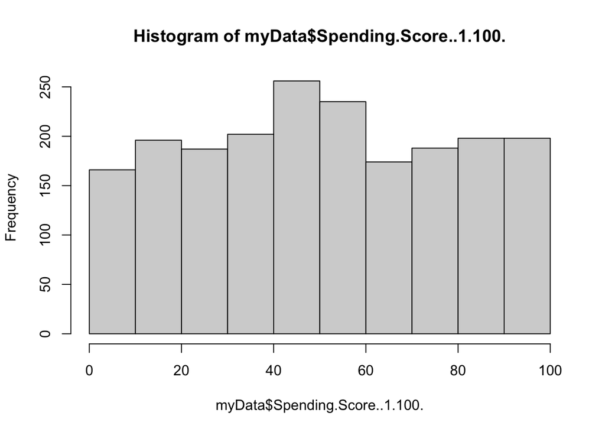

```r
hist(myData$Spending.Score..1.100.)
```

# Week 10 (Exam II Week)

## Friday March 31

### Two tail tests

Two tail tests:

Ha: !=

Ex) A researcher wonders if mean IQ for musicians DIFFERS from the general population (100).

Data: 50 musicians, their mean iq is 102.7, stdev 11.2.

Does this support claim/suspicion?

1. Hypotheses

H0: mu = 100 Ha: mu != 100

2. test stat

t = (obs - exp)/stdev

```r
(102.7-100)/(11.2/sqrt(50))
```

```
## [1] 1.704632
```

3. p-val

right tail area:

```r
1-pt(1.70, 49)
```

```
## [1] 0.04773554
```

p-val = 2*.048 = .096

4). conclusion

Since p-val > .05, we fail to reject H0. There’s insufficient evidence that mean iq for musicians differs from 100.

Q: when to use one-tail vs two tail?

A:

- read the language in problem (bigger/less/differ)
- in general, best to default to TWO TAIL test!

### Tests for TWO populations.

Ex) A researcher suspects that a higher proportion of DU students are from out-of-state than for Oberlin.

Data:

- Of 60 DU students, 51 were from out-of-state
- of 80 Ob studetns, 58 were from out-of-state

1). Hypotheses

H0: p1 - p2 = 0 Ha: p1 - p2 > 0

(p1 = DU prop, p2 = Ob prop)

2. test stat

z = (obs - exp)/stderr

```r
(51/60 - 58/80 - 0)/sqrt( 109/140*(1-109/140)/60 + 109/140*(1-109/140)/80)
```

```
## [1] 1.76279
```

3. p-val right tail area:

```r
1-pnorm(1.76)
```

```
## [1] 0.0392039
```

Interpret: If there’s no difference in proportion btwn DU and Ob, then there’s a 3.9% chance of observing a sample difference as extereme as ours.

4). Conclusion

Since p-val < .05, we reject H0. There’s strong evidence that the true proportion of out-of-state studetns at DU is higher than at Oberlin.

### 2-pop tests for mu1 - mu2

Ex) Prof Miller wonders, is there a difference in mean delivery time btwn Pizza Hut and Dominos?

Collect data about deliveries:

Of 23 PH deliveries, mean time was 23.4 min, stdev 6.3 min. Of 28 Dom deliveries, mean time was 27.9 min, stdev 9.4 min.

1. Hypotheses

H0: mu1 - mu2 = 0 (no difference) Ha: mu1 - mu2 != 0 (yes difference)

2. test stat

t = (obs-exp)/stderr

```r
(23.4 - 27.9 - 0)/sqrt( 6.3^2/23  +  9.4^2/28 )
```

```
## [1] -2.036769
```

3. p-val

Q: what’s df?

A: use the smaller of the two here: df = 23 - 1 = 22

left tail area:

```r
pt(-2.04, 22)
```

```
## [1] 0.02676758
```

p-val = 2* .026 = .052. (two tail test!)

4). Conclusion

Since p-val > .05, we fail to reject H0. There’s not strong evidence of a difference in mean delivery time.

# Week 11

## Monday April 3

### Confidence Intervals for two populations

Note about p1-p2: don’t use pooled estimate for CI. WE’RE NOT ASSUMING p1 = p2 !!!!

H0: p1 - p2 = 0. <- default assumption in Hyp test

In confidence interval, no assumptions. Trying to estimate the difference!

Ex) A researcher wonders: is there a higher proportion of registered Republicans in Licking county and Franklin county?

Collect data:

- Of 50 voters in Licking county, 32 were R
- Of 100 voters in Franklin, 51 were R

Estimate the difference in proportion of R voters btwn the two counties, with 95% confidence. Crit val: z = 1.96

```r
qnorm(.025)
```

```
## [1] -1.959964
```

low:

```r
32/50 - 51/100 - 1.96*sqrt( 32/50*(1-32/50)/50 + 51/100*(1-51/100)/100 )
```

```
## [1] -0.03523393
```

hi:

```r
32/50 - 51/100 + 1.96*sqrt( 32/50*(1-32/50)/50 + 51/100*(1-51/100)/100 )
```

```
## [1] 0.2952339
```

Interpret: we are 95% confident that the difference in prop of R voters is between -3.5% and 29.5%.

Since 0 is contained in the interval, there’s no strong evidence of a difference in proportion.

### Connection btwn Hyp Test and CI

If the value in H0 is contained in the CI, then FAIL TO REJECT H0!

Otherwise, reject.

### CI for two means

Ex) A reseracher wonders: is there a difference in mean ACT score btwn Licking county and Franklin county?

Data:

- In 50 random Licking students, mean act score was 21.3, stdev 5.4.
- In 80 random Franklin students, mean act score was 24.4, stdev 6.1.

Estimate the difference in mean ACT score with 95% confidence. critical value: t = 2.01

```r
qt(.025, 49)
```

```
## [1] -2.009575
```

low:

```r
21.3-24.4 - 2.01*sqrt(5.4^2/50 + 6.1^2/80)
```

```
## [1] -5.157994
```

hi:

```r
21.3-24.4 + 2.01*sqrt(5.4^2/50 + 6.1^2/80)
```

```
## [1] -1.042006
```

We’re 95% confident that the true difference in mean act score is btwn -5.2 and -1.0.

Looks like mu1-mu2=0 isn’t likely. We reject H0: there’s strong evidence of a difference in mean ACT score btwn Licking and Franklin.

Note: Hyp test and CI will always have same conclusion AS LONG AS ALPHA AND CONFIDENCE MATCH!!!

Ex: if alpha = .05, then use 95% confidence.

### Ch 12 - Linear Regression

Idea: compare TWO quant variables. (x,y)

main visualization: “scatterplot”. x-y plot of all data points.

Ex). mpg

```r
head(mpg)
```

```
## # A tibble: 6 × 11
##   manufacturer model displ  year   cyl trans      drv     cty   hwy fl    class
##   <chr>        <chr> <dbl> <int> <int> <chr>      <chr> <int> <int> <chr> <chr>
## 1 audi         a4      1.8  1999     4 auto(l5)   f        18    29 p     compa…
## 2 audi         a4      1.8  1999     4 manual(m5) f        21    29 p     compa…
## 3 audi         a4      2    2008     4 manual(m6) f        20    31 p     compa…
## 4 audi         a4      2    2008     4 auto(av)   f        21    30 p     compa…
## 5 audi         a4      2.8  1999     6 auto(l5)   f        16    26 p     compa…
## 6 audi         a4      2.8  1999     6 manual(m5) f        18    26 p     compa…
```

Make a scatterplot to visualize cty (x) and hwy (y)

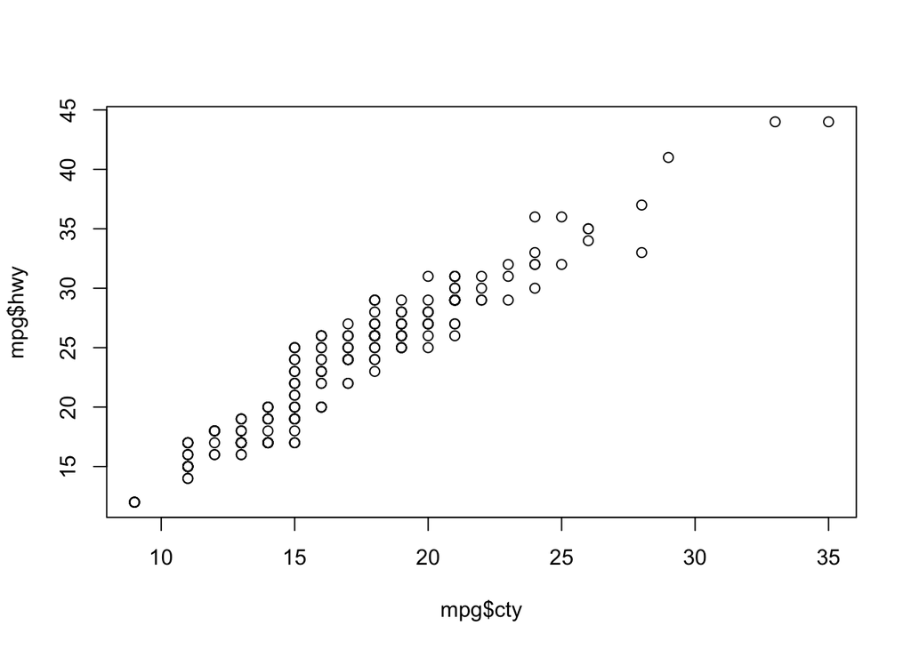

```r
plot(mpg$cty, mpg$hwy)
```

```r
cor(mpg$cty, mpg$hwy)
```

```
## [1] 0.9559159
```

Woah! Strong relationship! Makes sense - if more efficient in city, you’d expect more efficient on hwy.

Ex) Compare engine size (displ - x) with cty mpg (cty - y )

```r
plot(mpg$displ, mpg$cty)
```

[output not shown]

```r
cor(mpg$displ, mpg$cty)
```

```
## [1] -0.798524
```

Woah! Strong negative relationship! As engine size increases, mpg decreases. Makes sense.

Ex). iris data

```r
head(iris)
```

```
##   Sepal.Length Sepal.Width Petal.Length Petal.Width Species
## 1          5.1         3.5          1.4         0.2  setosa
## 2          4.9         3.0          1.4         0.2  setosa
## 3          4.7         3.2          1.3         0.2  setosa
## 4          4.6         3.1          1.5         0.2  setosa
## 5          5.0         3.6          1.4         0.2  setosa
## 6          5.4         3.9          1.7         0.4  setosa
```

Compare iris sepal length (x) and sepal width (y).

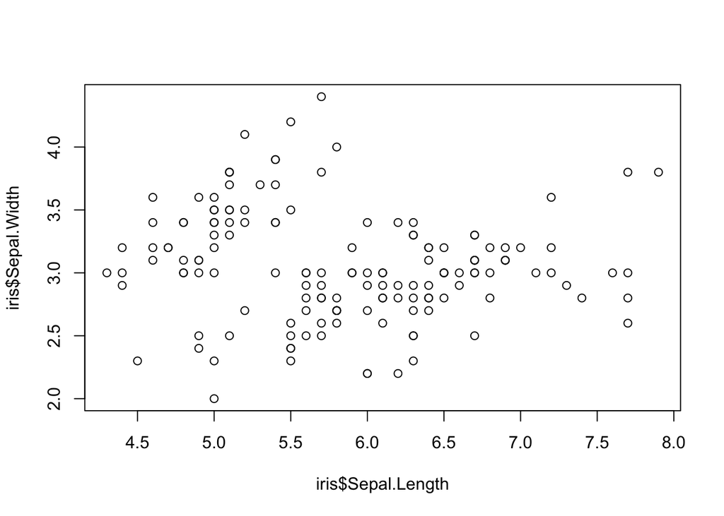

```r
plot(iris$Sepal.Length, iris$Sepal.Width)
```

```r
cor(iris$Sepal.Length, iris$Sepal.Width)
```

```
## [1] -0.1175698
```

Huh. No obvious relationship btwn sepal length and width. Weird but true.

### The linear correlation coefficient - r

Note: capitol “R” is the software. lower. “r” is the correlation coefficient

## Wed April 5

### Ch 12 - Linear Regression

Ex). mpg.

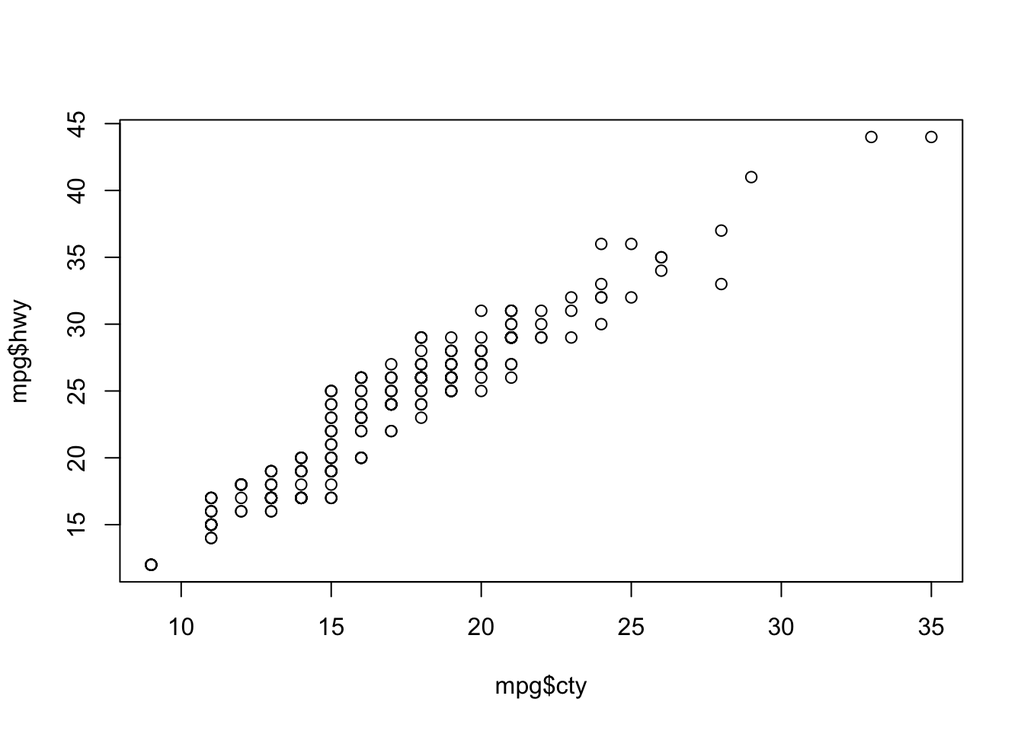

```r
plot(mpg$cty, mpg$hwy)
```

```r
cor(mpg$hwy, mpg$cty)
```

```
## [1] 0.9559159
```

### Linear Correlation Coefficient - r

r measures the STRENGTH and DIRECTION of a LINEAR relationship.

### Properties of corr coeff

- ```
   -1 <= r <= +1    for ANY variables x,y
  ```

- If r = 1, then PERFECT (colinear) POSITIVE LINEAR relationship
- Id r=-1, then perfect NEGATIVE LINEAR relationship
- If r~0, then no LINEAR relationship WARNING: always look at scatterplot with human eyeballs
- r isn’t affected by units (lbs/kgs, in/cm, mi/km)
- doesn’t matter which is x, which is y

### Least-squares line

Many names:

- best fit line
- trend line
- regression line
- etc etc

Good news: all the same! One UNIQUE “best” line!

Q: What makes it the “best”?

A: it minimizes the sum of the SQUARE RESIDUALS!

Note: the sum/average of residuals is ALWAYS ZERO!!!

### Computing equation for least squares

In linear model: we make predictions ABOUT y-variable, BASED UPON the x-variable.

x: input, independent variable y: output, dependedent variable

Be careful, it matters which is which!

Equation:

yhat = b0 + b1*x

where:

b0 = y-intercept b1 = slope

To compute:

1. Find slope

b1 = r*sy/sx

Note: if correlation is STRONGER, then slope is STEEPER! Ie, if strong relationship, then x has bigger effect on y!

2). find intercept

Neat fact: the line ALWAYS touches the point (xbar,ybar)

->

b0 = ybar - b1*xbar

Ex). Data: height and weight of 50 men.

Summary:

Height:

avg height = 70.1” stdev. = 3.6”

Weight:

avg weight = 165.2 lbs stdev. = 11.9 lbs

cor = r = 0.71

Find equation for linear model to predict weight based on height.

Here: x=height, y = weight

1. slope:

```r
.71*11.9/3.6
```

```
## [1] 2.346944
```

2. int

```r
165.2 - 2.35*70.1
```

```
## [1] 0.465
```

yhat = 0.465 + 2.34*x

```r
head(mpg)
```

```
## # A tibble: 6 × 11
##   manufacturer model displ  year   cyl trans      drv     cty   hwy fl    class
##   <chr>        <chr> <dbl> <int> <int> <chr>      <chr> <int> <int> <chr> <chr>
## 1 audi         a4      1.8  1999     4 auto(l5)   f        18    29 p     compa…
## 2 audi         a4      1.8  1999     4 manual(m5) f        21    29 p     compa…
## 3 audi         a4      2    2008     4 manual(m6) f        20    31 p     compa…
## 4 audi         a4      2    2008     4 auto(av)   f        21    30 p     compa…
## 5 audi         a4      2.8  1999     6 auto(l5)   f        16    26 p     compa…
## 6 audi         a4      2.8  1999     6 manual(m5) f        18    26 p     compa…
```

This is a good dataset: mixture/variety of BOTH categorical AND quantitative variables!

## Friday April 7

### Ch 12 - Lin Reg

Ex). mpg. Find equation for linear model for predicting cty (y) mpg based on engine size (displ -x ).

```r
head(mpg)
```

```
## # A tibble: 6 × 11
##   manufacturer model displ  year   cyl trans      drv     cty   hwy fl    class
##   <chr>        <chr> <dbl> <int> <int> <chr>      <chr> <int> <int> <chr> <chr>
## 1 audi         a4      1.8  1999     4 auto(l5)   f        18    29 p     compa…
## 2 audi         a4      1.8  1999     4 manual(m5) f        21    29 p     compa…
## 3 audi         a4      2    2008     4 manual(m6) f        20    31 p     compa…
## 4 audi         a4      2    2008     4 auto(av)   f        21    30 p     compa…
## 5 audi         a4      2.8  1999     6 auto(l5)   f        16    26 p     compa…
## 6 audi         a4      2.8  1999     6 manual(m5) f        18    26 p     compa…
```

Summary stats

xbar = 3.47 sx. = 1.29 ybar = 16.86 sy. = 4.26 r. = -0.80

1. slope = b1 = r*sy/sx = -2.64

```r
-.8*4.26/1.29
```

```
## [1] -2.64186
```

2. y-int = b0 = ybar - b1*xbar

```r
16.86 + 2.64*3.47
```

```
## [1] 26.0208
```

yhat = 26.02 - 2.64*x

```r
plot(mpg$displ, mpg$cty)
```

[output not shown]

### Making prediction with least squares line

Plug in x!

Ex). A particular car has a 2.8L engine. Predict its cty mpg.

plug in x=2.8:

```r
26.02 - 2.64*2.8
```

```
## [1] 18.628
```

```r
plot(mpg$displ, mpg$cty)
```

[output not shown]

Ex). Predict the cty mpg for a car with a 20.5L engine.

```r
26.02 - 2.64*20.5
```

```
## [1] -28.1
```

Can’t! Shouldn’t! EXTRAPOLATION: making predictions outside the observed range of data. BAD!

Junk in - junk out!

### Interpret the coefficients of linear model

Coeff: b0, b1

Slope: y=mx+b. If x increases by 1 unit, y inc/dec by m.

Lin reg: If [x-variable] increases by one [x-unit], then we predict/expect [y-variable] to inc/dec by [slope] [y-units].

For each additional L bigger a car’s engine is, we predict its city fuel efficiency to decrease by 2.64 mpg.

Intercept: if x=0, y = y-int

Lin reg: If [x-variable] is zero [x-units], then we predict/expect [y-variable] to be [y-int] [y units].

Car: If a car’s engine is 0L big (!!), we’d predict its city mpg to be 26.02 mpg.

EXTRAPOLATION! Not helpful.

### Coefficient of determination - r^2

r^2 = percentage of variation in the y-data that’s due to/because of the linear relationship btwn x and y.

Ex). compute and interpret r^2 for car model.

Of all the variation in city fuel efficiency, about 64% is due to the linear relationship between fuel efficiency and engine size.

compute:

```r
(-.8)^2
```

```
## [1] 0.64
```

### Residual Plots

residual = y - yhat obs - exp

Ex). car model. A particular car has an 3.5 L engine and gets 17mpg in city. Compute the residual for this car.

x = 3.5 y = 17

yhat:

```r
26.02 - 2.64*3.5
```

```
## [1] 16.78
```

resid:

```r
17 - 16.78
```

```
## [1] 0.22
```

Our model under-approximated the mpg by 0.22mpg.

Residual plot:

x-coords: original x-data y-coords: residuals!

Ex). construct resid plot for mpg model.

x-coords = mpg$displ

first: predicted yhat:

```r
yhat <- 26.02 - 2.64*mpg$displ
```

next: resids

```r
resids <- mpg$cty - yhat
```

resid plot:

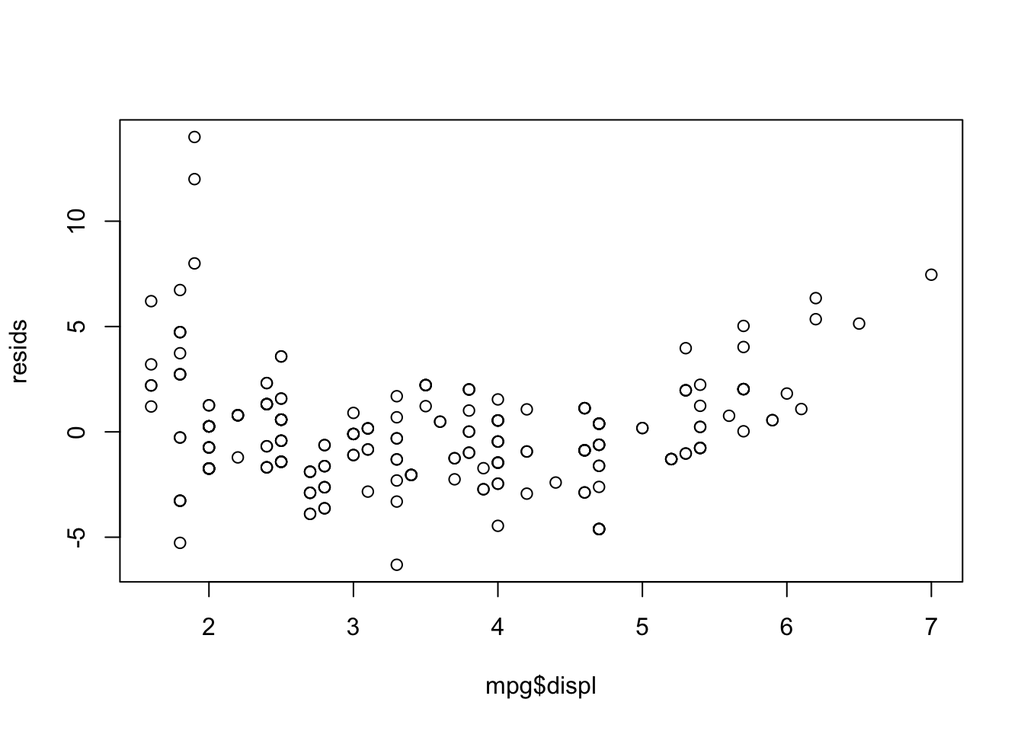

```r
plot(mpg$displ, resids)
```

# Week 12

## Monday April 10

### Residual Plots

In R - “lm” command.

Ex). Find linear model for predicting cty mpg based on displ (engine size).

**idea: lm( y ~ x )**

= “as a function of”

```r
mpgModel <- lm( cty ~ displ, data = mpg)
```

Trick: look at variables with $

Summary:

```r
summary(mpgModel)
```

```
##
## Call:
## lm(formula = cty ~ displ, data = mpg)
##
## Residuals:
##     Min      1Q  Median      3Q     Max
## -6.3109 -1.4695 -0.2566  1.1087 14.0064
##
## Coefficients:
##             Estimate Std. Error t value Pr(>|t|)
## (Intercept)  25.9915     0.4821   53.91   <2e-16 ***
## displ        -2.6305     0.1302  -20.20   <2e-16 ***
## ---
## Signif. codes:  0 '***' 0.001 '**' 0.01 '*' 0.05 '.' 0.1 ' ' 1
##
## Residual standard error: 2.567 on 232 degrees of freedom
## Multiple R-squared:  0.6376, Adjusted R-squared:  0.6361
## F-statistic: 408.2 on 1 and 232 DF,  p-value: < 2.2e-16
```

Residual plot:

x: original x data y: residuals (from model)

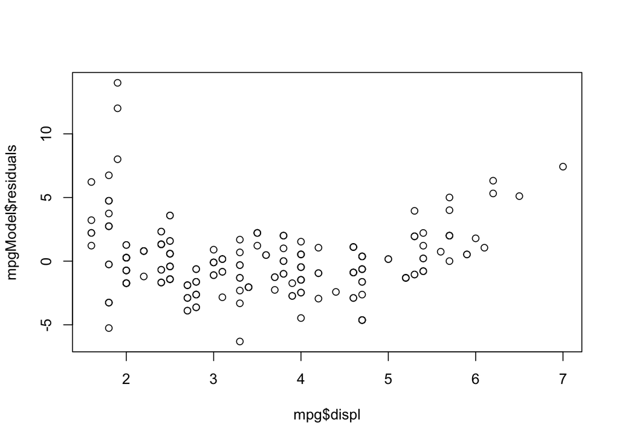

```r
plot(mpg$displ, mpgModel$residuals)
```

### Interpreting residual plots

Here’s what you DON’T want to see:

1). A pattern (ex: curve-shaped). Idea: A pattern in the residuals means that the errors are PREDICTABLE. Suggests linear model isn’t the best.

2. Heteroskedasticity. Idea: we hope that residuals have CONSTANT MAGNITUDE across the range of observations (homoskedastic). If heteroskedastic, suggests the linear model is failing in some parts of the range. Bad!

Example:

Ex). Data = house sales. Make model to predict price based on sqft_living.

```r
houseData <- read.csv("./House-Sales.csv")
houseModel <- lm( price ~ sqft_living, data = houseData)
```

residuals:

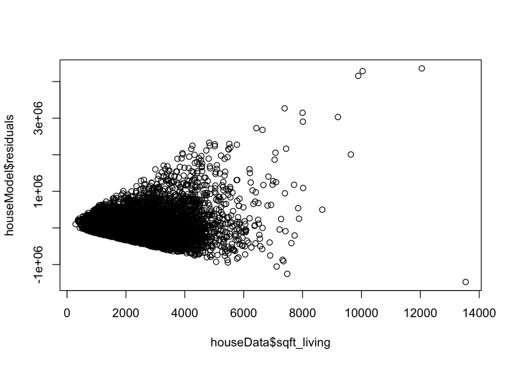

```r
plot(houseData$sqft_living, houseModel$residuals)
```

Google image: “heteroscestic residuals”

In general: you HOPE your residuals are a “blob”. Best case scenario.

Ex) mpg. x=cty, y=hwy.

residuals:

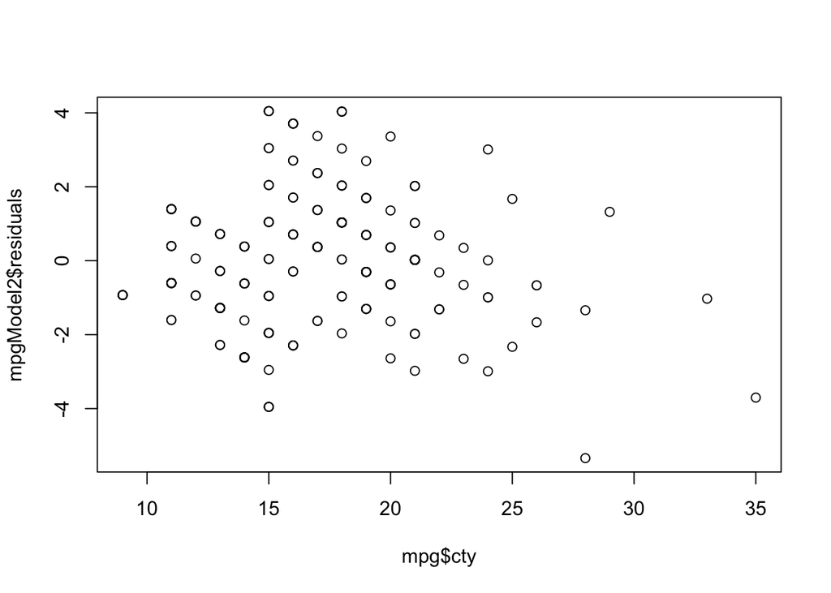

```r
mpgModel2 <- lm(hwy ~ cty, data = mpg)
plot(mpg$cty, mpgModel2$residuals)
```

Ah! No pattern, roughly homoskedastic. Good residuals!

### Distribution of residuals

Idea: we hope that residuals follow a normal dist.

Ie: most close to zero, unlikely to be large.

Ex). mpg. x=cty, y=hwy.

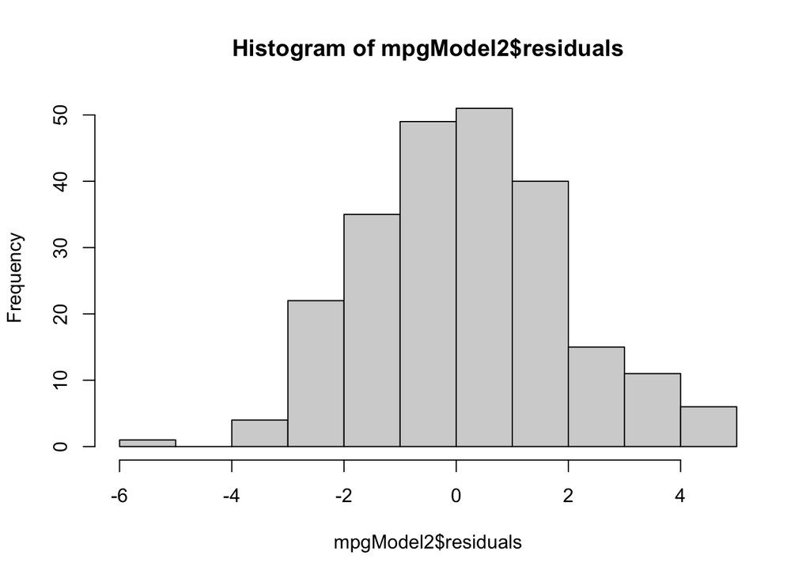

```r
hist(mpgModel2$residuals)
```

Good resids! Roughly symmetric and unimodal!

Ex). mpg. x=displ, y=cty.

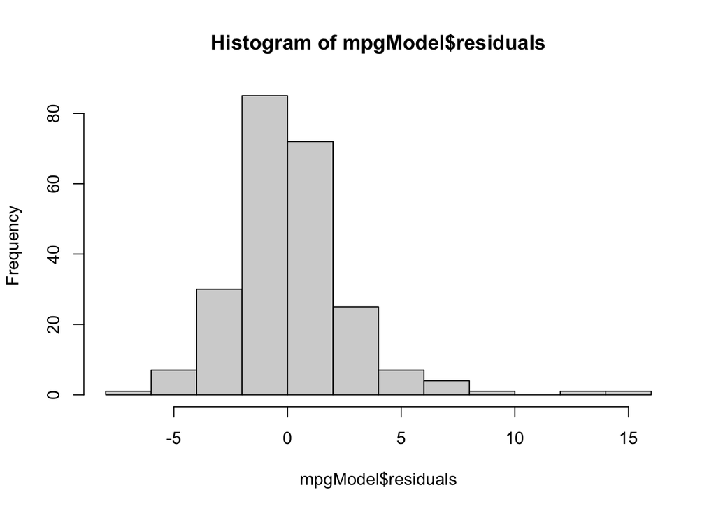

```r
hist(mpgModel$residuals)
```

### Multiple Linear Regression

Idea: more variables!

In R: use “+” in the lm command.

Ex). house sales. first: predict price based on bedrooms

```r
houseModel1 <- lm(price~bedrooms, data=houseData)
summary(houseModel1)
```

```
##
## Call:
## lm(formula = price ~ bedrooms, data = houseData)
##
## Residuals:
##      Min       1Q   Median       3Q      Max
## -3508706  -203228   -66728   104982  6839614
##
## Coefficients:
##             Estimate Std. Error t value Pr(>|t|)
## (Intercept)   129649       8938   14.51   <2e-16 ***
## bedrooms      121790       2556   47.65   <2e-16 ***
## ---
## Signif. codes:  0 '***' 0.001 '**' 0.01 '*' 0.05 '.' 0.1 ' ' 1
##
## Residual standard error: 349500 on 21611 degrees of freedom
## Multiple R-squared:  0.09507,    Adjusted R-squared:  0.09503
## F-statistic:  2270 on 1 and 21611 DF,  p-value: < 2.2e-16
```

Interpret slope: For each additional bedroom, we predict the house’s price to increase by $121,790.

y-int: If a house has zero bedrooms (hmm….), we predict its price to be 129,649. Extrapolation.

Note: r^2 = .095. Low! Seems like bedrooms alone don’t account for much of the price.

Ex 2). Predict price based on bedrooms and bathrooms.

```r
houseModel2 <- lm(price ~ bedrooms + bathrooms, data = houseData)
summary(houseModel2)
```

```
##
## Call:
## lm(formula = price ~ bedrooms + bathrooms, data = houseData)
##
## Residuals:
##      Min       1Q   Median       3Q      Max
## -1484922  -184520   -42472   111528  5919466
##
## Coefficients:
##             Estimate Std. Error t value Pr(>|t|)
## (Intercept)   -30900       8276  -3.734 0.000189 ***
## bedrooms       20146       2666   7.557 4.27e-14 ***
## bathrooms     237934       3219  73.912  < 2e-16 ***
## ---
## Signif. codes:  0 '***' 0.001 '**' 0.01 '*' 0.05 '.' 0.1 ' ' 1
##
## Residual standard error: 312200 on 21610 degrees of freedom
## Multiple R-squared:  0.2777, Adjusted R-squared:  0.2776
## F-statistic:  4154 on 2 and 21610 DF,  p-value: < 2.2e-16
```

Ok, better! Now explaining 28% of sale price.

Ex3). Predict price based on bedrooms AND bathrooms AND sqft_living

```r
houseModel3 <- lm(price~bedrooms+bathrooms+sqft_living, data=houseData)
summary(houseModel3)
```

```
##
## Call:
## lm(formula = price ~ bedrooms + bathrooms + sqft_living, data = houseData)
##
## Residuals:
##      Min       1Q   Median       3Q      Max
## -1644794  -144361   -22891   102420  4178611
##
## Coefficients:
##               Estimate Std. Error t value Pr(>|t|)
## (Intercept)  74662.099   6917.977  10.792   <2e-16 ***
## bedrooms    -57906.631   2336.062 -24.788   <2e-16 ***
## bathrooms     7928.708   3512.744   2.257    0.024 *
## sqft_living    309.605      3.089 100.238   <2e-16 ***
## ---
## Signif. codes:  0 '***' 0.001 '**' 0.01 '*' 0.05 '.' 0.1 ' ' 1
##
## Residual standard error: 258000 on 21609 degrees of freedom
## Multiple R-squared:  0.5069, Adjusted R-squared:  0.5069
## F-statistic:  7406 on 3 and 21609 DF,  p-value: < 2.2e-16
```

Best yet! This model explains over 50% of the variation in the y variable.

Idea for multiple variables: hunt for the variables that give highest R^2 value!